# Hierarchical Clustering and Centrality Measures on Crime Organization Graph

Faathir Chikal Asyuraa

11/30/2019

# 1 Introduction

## 1.1 About this project

On this project the author and his team has gathered data on international crime organizations from Wikipedia.org, and represent the data in a graph format, with the nodes are the organization, and an edge means that there are connection between two organizations, it is weighted according to how much they have same criminal activites and whether they work on the same area or not

The data consist of 154 nodes and 288 edges

## 1.2 Libraries used

```r
library(readr) # Reading datafile
library(readxl) # Reading excel
library(igraph) # Core graph package
library(tidyverse) # Data mungings
library(ggraph) # Graph Visualization
library(ggdendro) # Dendogram Visualization of hierarchical clustering
library(dendextend) # Additional extension on the dendogram visualization
library(visNetwork) # Interactive Visualization on graph
```

# 2 Data Exploration & Preprocessing

## 2.1 Reading the data

```r
# Read the nodes file into the variable nodes
nodes <- read_excel('Nodes.xlsx')

# Read the ties file into the variable ties
ties <- read_excel('Edges_Ready.xlsx')
```

## 2.2 Take a quick look at the graph dataframe

```r
# Print nodes
nodes
```

| id | name |
| --- | --- |
| 1 | Camorra |
| 2 | Sicilian Mafia |
| 3 | Ndrangheta |
| 4 | Sacra Corona Unita |
| 5 | Società Foggiana |
| 6 | British firms |
| 7 | Albanian mafia |
| 8 | Nigerian crime gangs |
| 9 | Juárez Cartel |
| 10 | Banda della Magliana |

[output cut: 144 more lines]

```r
# Print ties
ties
```

| from | to | weight |
| --- | --- | --- |
| 23 | 53 | 1 |
| 67 | 128 | 1 |
| 84 | 134 | 1 |
| 89 | 143 | 1 |
| 134 | 136 | 1 |
| 149 | 154 | 1 |
| 6 | 144 | 2 |
| 8 | 22 | 2 |
| 13 | 23 | 2 |
| 20 | 43 | 2 |

[output cut: 278 more lines]

## 2.3 Converting the dataframe into a graph object

```r
# Make the network from the data frame ties and print it
g <- graph_from_data_frame(ties,
                           directed = FALSE,
                           vertices = nodes)

# Explore the set of nodes
head(V(g))
```

```
## + 6/154 vertices, named, from 03b691e:
## [1] Camorra            Sicilian Mafia     Ndrangheta
## [4] Sacra Corona Unita Società Foggiana   British firms
```

```r
vcount(g)
```

```
## [1] 154
```

```r
# Explore the set of ties
head(E(g))
```

```
## + 6/288 edges from 03b691e (vertex names):
## [1] Chaldean Mafia                                       --Detroit Partnership
## [2] Mexican Mafia                                        --White Fence
## [3] Philadelphia crime family / Bruno-Scarfo crime family--Warlocks
## [4] Buffalo crime family                                 --Papalia crime family
## [5] Warlocks                                             --Pagans
## [6] Cuntrera-Caruana Mafia clan                          --Corleonesi Mafia clan
```

```r
ecount(g)
```

```
## [1] 288
```

```r
# Give the name "Cartels" to the network
g$name <- "Cartels"

# Add node attribute id and print the node `id` attribute
V(g)$id <- 1:vcount(g)

# Print the tie `weight` attribute
head(E(g)$weight)
```

```
## [1] 1 1 1 1 1 1
```

# 3 Centrality Measures

## 3.1 Assigning proper weight on edges for calculating distances between to vertex

In our data, larger weight measure how much two organization do the same criminal activities and done their criminal activities in the same area.

In many graph algrotihm, edge weight are treated like ‘cost’ to cross that edge, meaning that larger value are more costly to cross

But in our data, larger weight value means stronger bond

So, to tackle that, we take the inverse of our weight so it is still use the same principle that ‘the smaller the (inverse of) weight (means stronger bonds), the less it cost to get information across’

```r
# Calculate the reciprocal of the tie weights
dist_weight <- 1 / E(g)$weight
```

## 3.2 Creating centrality measures

we’ll start with degree

```r
nodes_with_centrality <- nodes %>%
  # Add a column containing the degree of each node
  mutate(degree = degree(g)) %>%
  # Arrange rows by descending degree
  arrange(desc(degree))
# See the result
nodes_with_centrality
```

| id | name | degree |
| --- | --- | --- |
| 29 | Sinaloa Cartel | 15 |
| 84 | Philadelphia crime family / Bruno-Scarfo crime family | 14 |
| 85 | Genovese crime family | 14 |
| 38 | Gambino crime family | 13 |
| 2 | Sicilian Mafia | 11 |
| 44 | Juggalos | 11 |
| 86 | Colombo crime family | 11 |
| 90 | Chicago Outfit | 11 |
| 1 | Camorra | 10 |
| 13 | Italian-American mafia | 10 |

[output cut: 144 more lines]

## 3.3 Adding vertex betweenness and closeness

```r
nodes_with_centrality <- nodes %>%
  mutate(
    degree = degree(g),
    # Add a column containing the strength of each node
    strength = strength(g),
    # Betweenness
    betweenness = betweenness(g,weights = dist_weight),
    # Closeness
    closeness = closeness(g,weights = dist_weight)
  ) %>%
  # Arrange rows by descending strength
  arrange(desc(betweenness))

# Adding the strength, degree, and closeness on nodes data
nodes$degree <- degree(g)
nodes$strength <- strength(g)
nodes$closeness <- closeness(g,weights = dist_weight)

# See the result
nodes_with_centrality
```

| id | name | degree | strength | betweenness | closeness |
| --- | --- | --- | --- | --- | --- |
| 2 | Sicilian Mafia | 11 | 107 | 2328.50 | 1.418597e-03 |
| 44 | Juggalos | 11 | 56 | 2137.00 | 1.387337e-03 |
| 78 | Sureños | 7 | 47 | 2086.75 | 1.410977e-03 |
| 59 | Serbian mafia | 6 | 49 | 2079.25 | 1.420622e-03 |
| 115 | Hells Angels | 8 | 48 | 1860.50 | 1.385245e-03 |
| 1 | Camorra | 10 | 129 | 1654.00 | 1.420754e-03 |
| 120 | Trafficante crime family | 2 | 14 | 1520.25 | 1.399563e-03 |
| 139 | New Orleans crime family | 4 | 25 | 1451.75 | 1.379902e-03 |
| 13 | Italian-American mafia | 10 | 97 | 1428.00 | 1.420085e-03 |
| 29 | Sinaloa Cartel | 15 | 75 | 1315.50 | 1.397470e-03 |

[output cut: 144 more lines]

## 3.4 Creating histograms of centrality measures on a vertex

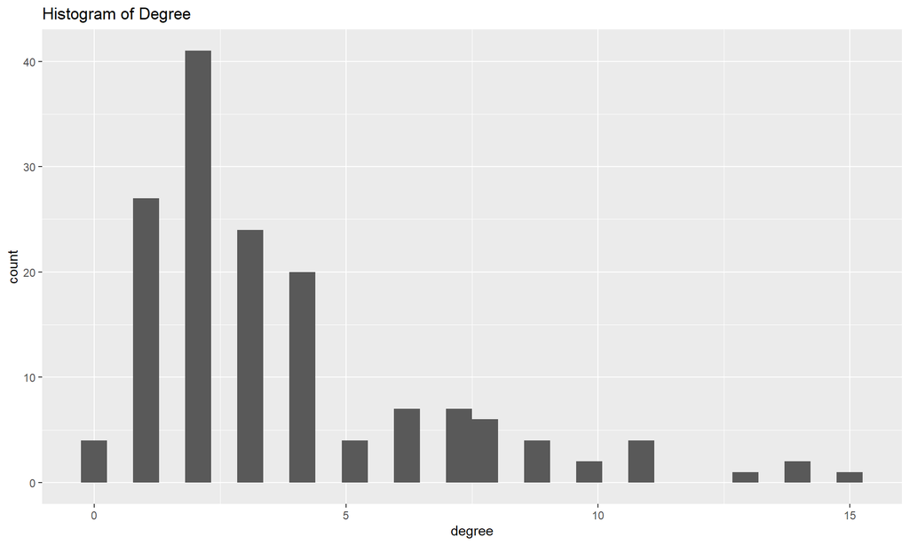

```r
nodes_with_centrality %>%
  ggplot(aes(x = degree))+
  geom_histogram()+
  ggtitle('Histogram of Degree')
```

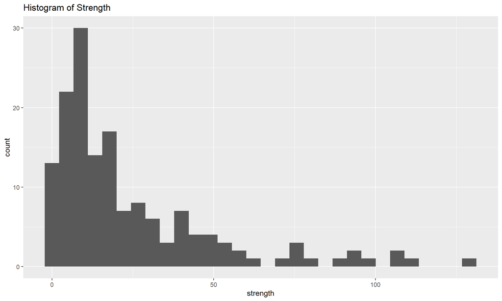

```r
nodes_with_centrality %>%
  ggplot(aes(x = strength))+
  geom_histogram()+
  ggtitle('Histogram of Strength')
```

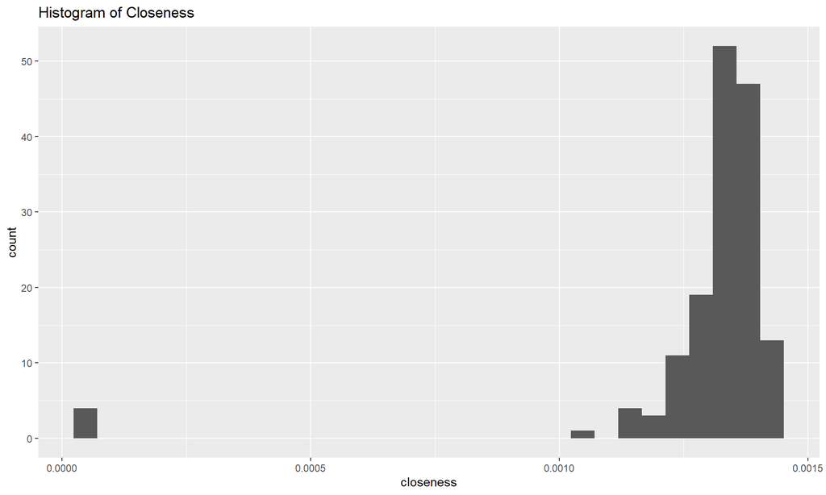

```r
nodes_with_centrality %>%
  ggplot(aes(x = closeness))+
  geom_histogram()+
  ggtitle('Histogram of Closeness')
```

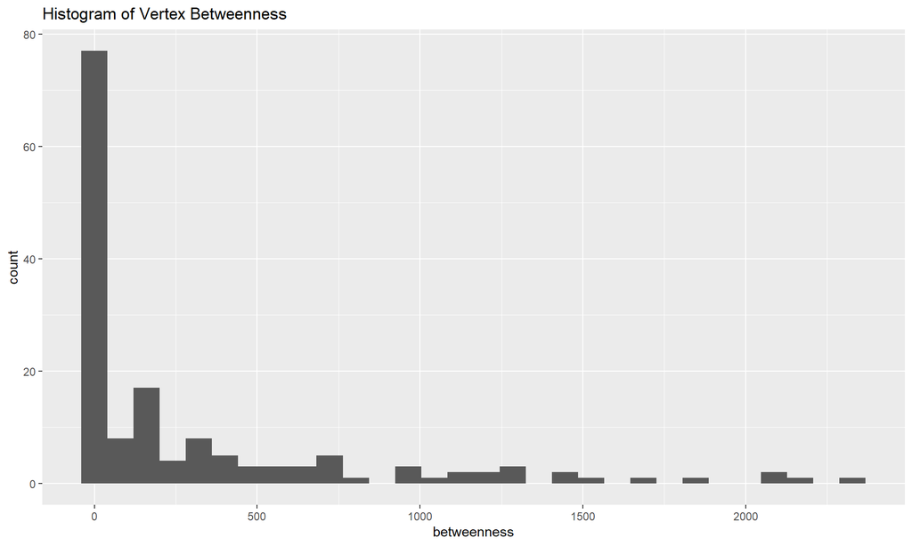

```r
nodes_with_centrality %>%
  ggplot(aes(x=betweenness))+
  geom_histogram()+
  ggtitle('Histogram of Vertex Betweenness')
```

## 3.5 Edge betweenness

```r
ties_with_betweenness <- ties %>%
  # Add an edge betweenness column weighted by dist_weight
  mutate(betweenness = edge_betweenness(g, weights = dist_weight))

# Review updated ties
ties_with_betweenness
```

| from | to | weight | betweenness |
| --- | --- | --- | --- |
| 23 | 53 | 1 | 4.00 |
| 67 | 128 | 1 | 149.00 |
| 84 | 134 | 1 | 148.00 |
| 89 | 143 | 1 | 149.00 |
| 134 | 136 | 1 | 1.00 |
| 149 | 154 | 1 | 149.00 |
| 6 | 144 | 2 | 149.00 |
| 8 | 22 | 2 | 149.00 |
| 13 | 23 | 2 | 34.50 |
| 20 | 43 | 2 | 147.00 |

[output cut: 278 more lines]

# 4 Distance Matrix

## 4.1 Creating distance matrix

here we’ll create a similarity matrix, made from spearman correlation from the adjacency matrix

(I actually tried several distance matrix like euclidean, manhattan, minkowski, but the following dendogram and the visualization in the end didn’t look to good. as of why the particular similarity measure is chosen, i didn’t delve much further. So my recommendation for future analysis, try to explore another distance measure, and select the appropriate one for dealing with adjacency matrix)

(Why spearman? spearman are non-parametric, so it does not assume much like pearson correlation [normality of the data])

```r
# Get the weighted adjacency matrix
A <- as_adjacency_matrix(g, attr = "weight", names = FALSE)

# convert it as a matrix
A <- as.matrix(A)
# Compute the Spearman correlation matrix of A
S <- cor(A,method="spearman")
## Warning in cor(A, method = "spearman"): the standard deviation is zero
# Assign the diagonal to zero
diag(S) <- 0
```

## 4.2 Create a ‘distance’ matrix

```r
D <- 1 - S
# Some of the nodes are not connected, so if there are any NAs, we'll replace it with 1 (very far)
D[is.na(D)] <- 1

# Obtain a distance object
d <- as.dist(D)
```

# 5 Hierarchical Clustering

## 5.1 Run the Hierarchical Clustering with the provided distance object

for the selection of the linkage, i tried some of the criterion and decided that the ‘complete’ method gives the best dendogram

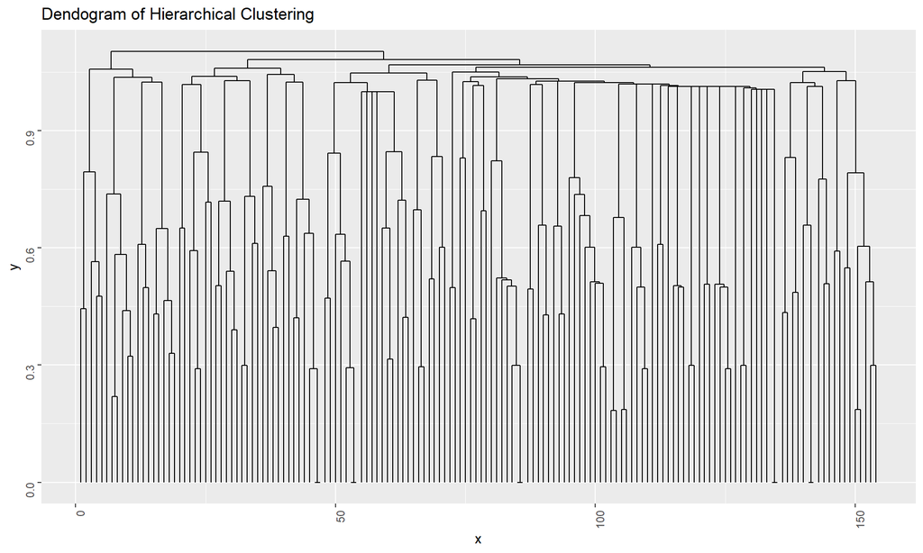

```r
# Run complete-linkage clustering method and plot the dendrogram
cc <- hclust(d, method = "complete")
dend <- as.dendrogram(cc)
ggdendrogram(dend,
             labels=FALSE,
             theme_dendro = FALSE)+
  ggtitle('Dendogram of Hierarchical Clustering')
```

## 5.2 Choosing the right amount of cluster

It looks like 5 cluster is appropriate for the above dendogram

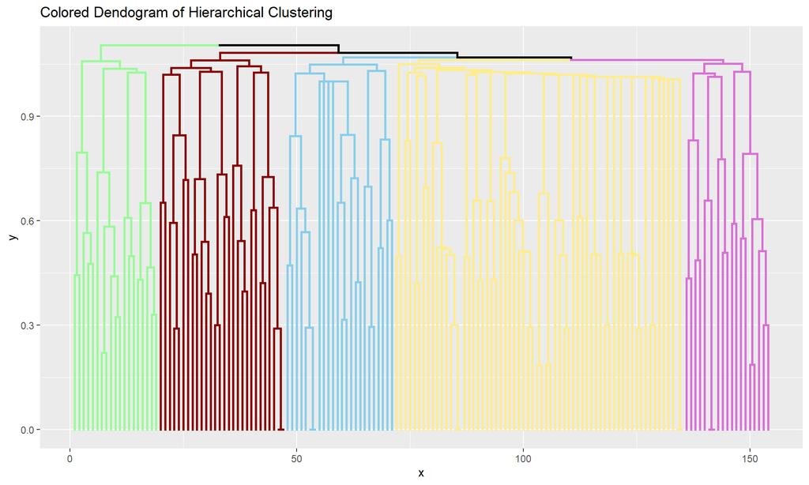

```r
dend1 <- dend %>% set("branches_k_color",
             value = c("palegreen","red4","skyblue","lightgoldenrod1","orchid"),
             k = 5)
dend1 <- as.dendrogram(dend1)
ggplot(dend1,
       theme=NULL,
       labels=FALSE)+ggtitle('Colored Dendogram of Hierarchical Clustering')
```

## 5.3 Creating 5 Cluster

```r
# Cut the dendrogram tree into 5 clusters
cls <- cutree(cc,
              k = 5)

# Add cluster information to nodes
nodes_with_clusters <- nodes %>%
  mutate(cluster = cls)
```

## 5.4 Calculate properties of each cluster

```r
nodes_with_clusters %>%
  # Group by cluster
  group_by(cluster) %>%
  # Calculate summary statistics
  summarize(
    # Number of nodes
    size = n(),
    # Median degree
    median_degree = median(degree),
    # Median strength
    median_strength = median(strength),
    # Median closeness
    median_closeness = median(closeness)
  ) %>%
  # Arrange rows by decreasing size
  arrange(desc(size))
```

| cluster | size | median_degree | median_strength | median_closeness |
| --- | --- | --- | --- | --- |
| 2 | 64 | 2 | 11.0 | 0.001329858 |
| 3 | 28 | 3 | 17.5 | 0.001364052 |
| 1 | 24 | 3 | 21.5 | 0.001396014 |
| 4 | 19 | 7 | 43.0 | 0.001346720 |
| 5 | 19 | 3 | 14.0 | 0.001342713 |

## 5.5 Each cluster charateristic

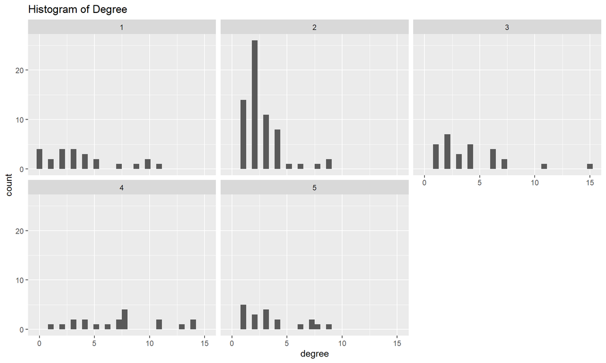

```r
nodes_with_clusters%>%ggplot(aes(x=degree))+geom_histogram()+ggtitle('Histogram of Degree')+facet_wrap(~cluster)
```

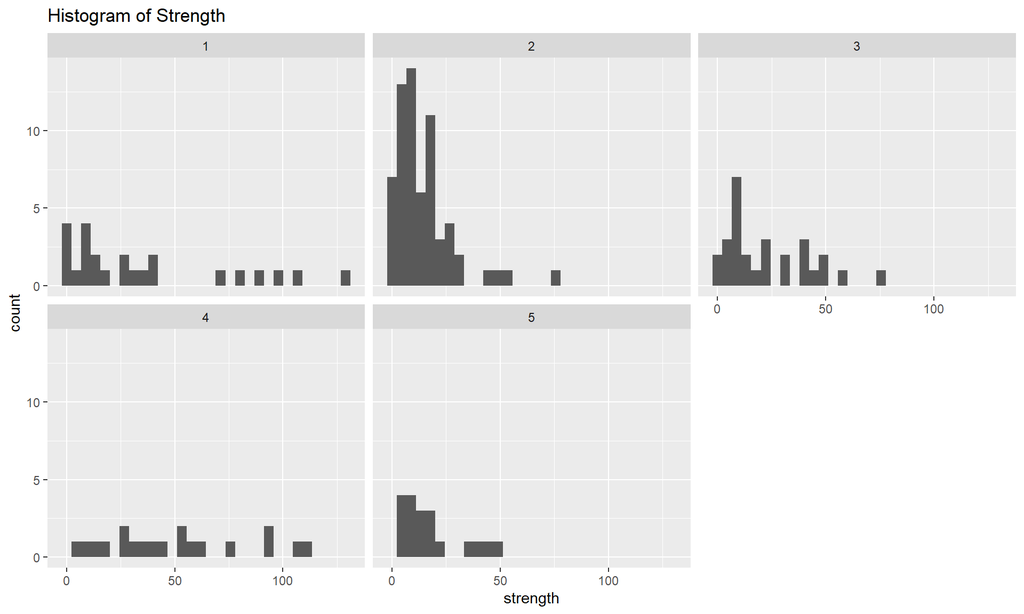

```r
nodes_with_clusters%>%ggplot(aes(x=strength))+geom_histogram()+ggtitle('Histogram of Strength')+facet_wrap(~cluster)
```

## 5.6 Assign cluster to each vertex

```r
V(g)$cluster <- nodes_with_clusters$cluster
```

# 6 Interactive Visualization

## 6.1 Converting the graph data to visNetwork Data for Interactive visualization

```r
data <- toVisNetworkData(g)

# Print the head of the data nodes
head(data$nodes)
```

|  | id | cluster | label |
| --- | --- | --- | --- |
| Camorra | Camorra | 1 | Camorra |
| Sicilian Mafia | Sicilian Mafia | 1 | Sicilian Mafia |
| Ndrangheta | Ndrangheta | 1 | Ndrangheta |
| Sacra Corona Unita | Sacra Corona Unita | 1 | Sacra Corona Unita |
| Società Foggiana | Società Foggiana | 1 | Società Foggiana |
| British firms | British firms | 2 | British firms |

```r
# ... do the same for the edges (ties)
head(data$edges)
```

|  | from | to | weight |
| --- | --- | --- | --- |
| 1 | Chaldean Mafia | Detroit Partnership | 1 |
| 2 | Mexican Mafia | White Fence | 1 |
| 3 | Philadelphia crime family / Bruno-Scarfo crime family | Warlocks | 1 |
| 4 | Buffalo crime family | Papalia crime family | 1 |
| 5 | Warlocks | Pagans | 1 |
| 6 | Cuntrera-Caruana Mafia clan | Corleonesi Mafia clan | 1 |

## 6.2 Assign labels

```r
nodes$id <- data$nodes$id
nodes$label <- data$nodes$id
nodes <- data$nodes
edges <- data$edges
```

## 6.3 Visualize the base network

```r
visNetwork::visNetwork(nodes,
                       edges,
                       width = 1000,
                       height = 1000)
```

[interactive chart not shown]

## 6.4 Adding strength value to the nodes

Now the nodes size will vary according to it’s strength value

```r
strength_value <- strength(g)
nodes$value <- strength_value[match(nodes$id,
                                    names(strength_value))]
nodes$value <- strength_value
```

## 6.5 Adding Visualization based on strength

```r
visNetwork::visNetwork(nodes,
                       edges,
                       width = 1000,
                       height = 1000)
```

[interactive chart not shown]

## 6.6 Adding Visualization based on edge betweenness

```r
edges$value <- edge_betweenness(g)
visNetwork::visNetwork(nodes,
                       edges,
                       width = 1000,
                       height = 1000)
```

[interactive chart not shown]

## 6.7 Coloring by cluster

```r
V(g)$color <- V(g)$cluster
nodes$group <- data$nodes$cluster
graph_crime_jelly <- visNetwork::visNetwork(nodes,
                                            edges,
                                            width = 1500,
                                            height=1000)%>%
  # Change options to select by group
  visOptions(selectedBy = "group",
             highlightNearest = TRUE)
graph_crime_jelly
```

[interactive chart not shown]

# 7 Exporting it to HTML

I named it graph jelly because the default algorithm will dynamically move the nodes until it converge automatically for the ‘best’ layout, and when you want to move the node, it will shake like jelly

You could check it out for yourself! all files are saved in bit.ly/ProjectDatminFaathir

## 7.1 White background

```r
visSave(graph_crime_jelly,
        'graph_crime_jelly.html',
        selfcontained = TRUE)
```

## 7.2 Black background

```r
visSave(graph_crime_jelly,
        'graph_crime_jelly_black.html',
        selfcontained = TRUE,
        background = "black")
```

End of Notebook Best regards, Faathir Chikal Asyuraa